# Lab_4

Abhinav Garg

2/16/2017

## Load Data

```r
data <- read.csv("census_data.csv")
data$income.g50 <- rep(0, nrow(data))
data$income.g50[data$income==" >50K"] <- 1
```

## Exploring Relationships

```r
mod <- glm(income.g50 ~ education + age + sex + race,
data=data[,!colnames(data)%in%"income"], family="binomial")
```

```r
summary(mod)
```

```
##
## Call:
## glm(formula = income.g50 ~ education + age + sex + race, family = "binomial",
##     data = data[, !colnames(data) %in% "income"])
##
## Deviance Residuals:
##     Min       1Q   Median       3Q      Max
## -2.4997  -0.6802  -0.4460  -0.1114   2.8328
##
## Coefficients:
##                           Estimate Std. Error z value Pr(>|z|)
## (Intercept)              -6.865618   0.504710 -13.603  < 2e-16 ***
## education 11th            0.296538   0.327880   0.904  0.36578
## education 12th            0.724955   0.386826   1.874  0.06092 .
## education 1st-4th        -0.180178   0.656420  -0.274  0.78371
## education 5th-6th        -1.065786   0.638832  -1.668  0.09525 .
## education 7th-8th        -0.055193   0.344602  -0.160  0.87275
## education 9th            -0.472650   0.422347  -1.119  0.26310
## education Assoc-acdm      1.793180   0.276081   6.495 8.30e-11 ***
## education Assoc-voc       1.806001   0.265792   6.795 1.08e-11 ***
## education Bachelors       2.498991   0.246065  10.156  < 2e-16 ***
## education Doctorate       3.465742   0.316322  10.956  < 2e-16 ***
## education HS-grad         1.099579   0.244388   4.499 6.82e-06 ***
## education Masters         2.910088   0.256902  11.328  < 2e-16 ***
## education Preschool     -10.727247 130.041047  -0.082  0.93426
## education Prof-school     3.834590   0.308031  12.449  < 2e-16 ***
## education Some-college    1.590668   0.246311   6.458 1.06e-10 ***
## age                       0.043369   0.002061  21.043  < 2e-16 ***
## sex Male                  1.291684   0.066444  19.440  < 2e-16 ***
## race Asian-Pac-Islander   1.009867   0.457049   2.210  0.02714 *
## race Black                1.119303   0.442857   2.527  0.01149 *
## race Other                0.213828   0.654001   0.327  0.74370
## race White                1.392564   0.431938   3.224  0.00126 **
## ---
## Signif. codes:  0 '***' 0.001 '**' 0.01 '*' 0.05 '.' 0.1 ' ' 1
##
## (Dispersion parameter for binomial family taken to be 1)
##
##     Null deviance: 11151.2  on 9999  degrees of freedom
## Residual deviance:  8900.2  on 9978  degrees of freedom
## AIC: 8944.2
##
## Number of Fisher Scoring iterations: 12
```

## a.)

The log odds ratio for having a master’s degree is 2.91 and for having 1st to 4th grade education is -0.18

The p-value for Master’s degree is < 2e -16 hence it is statistically significant but the p-value for 1st - 4th grade education is 0.78371 hence there is more probability that this is by chance.

## b.)

P-values for both age and sex are < 2e-16 therefore they are both statistically significant and are practically significant as age and sex do determine a person’s income

## 3

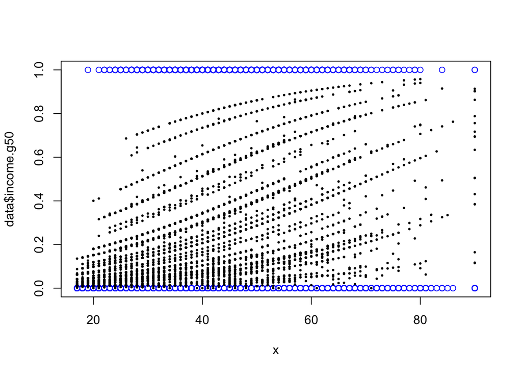

```r
x <- data$age
plot(x, data$income.g50, col="blue")
fits <- fitted(mod)
points(x, fits, pch=19, cex=0.3)
```

The predicted outcomes are so variable because although age is on the x-axis the other variables vary and that’s why we don’t have just one sigmoid line

## 4

```r
tab <- table(data$income.g50, fits>=0.25)
(tab[1,2]+tab[2,1])/sum(tab)
```

```
## [1] 0.2662
```

```r
tab <- table(data$income.g50, fits>=0.5)
(tab[1,2]+tab[2,1])/sum(tab)
```

```
## [1] 0.2061
```

```r
tab <- table(data$income.g50, fits>=0.75)
(tab[1,2]+tab[2,1])/sum(tab)
```

```
## [1] 0.2307
```

The cutoff with 0.5 has lowest percent error

## 5

```r
library(AUC)
```

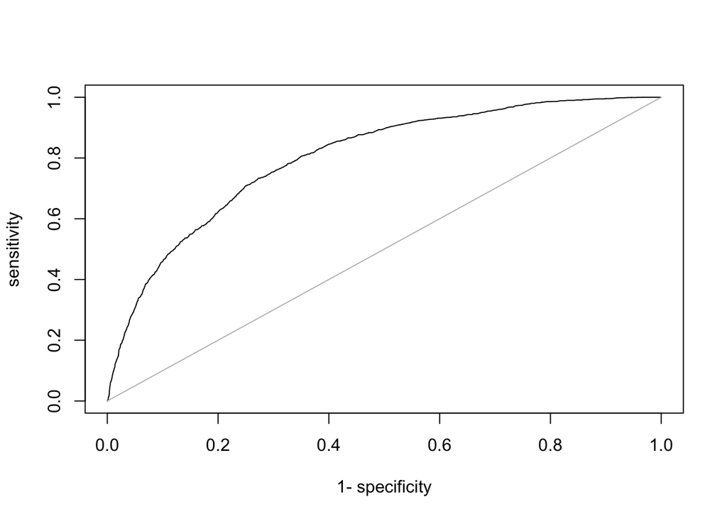

```r
y <- factor(data$income.g50)
rr <- roc(fits, y)
plot(rr)
```

```r
auc(rr)
```

```
## [1] 0.8021133
```

2. How well does it fit?

The model fits well as the AUC is 0.802

## 6

```r
mod <- glm(income.g50~.,
data=data[,!colnames(data)%in%c("income")], family="binomial")
summary(mod)
```

```
##
## Call:
## glm(formula = income.g50 ~ ., family = "binomial", data = data[,
##     !colnames(data) %in% c("income")])
##
## Deviance Residuals:
##     Min       1Q   Median       3Q      Max
## -2.6128  -0.5605  -0.2026  -0.0001   3.2983
##
## Coefficients: (2 not defined because of singularities)
##                                             Estimate Std. Error z value
## (Intercept)                               -9.931e+00  7.766e-01 -12.787
## age                                        2.801e-02  2.783e-03  10.062
## work.class Federal-gov                     1.071e+00  2.656e-01   4.032
## work.class Local-gov                       1.906e-01  2.418e-01   0.789
## work.class Never-worked                   -1.359e+01  9.580e+02  -0.014
## work.class Private                         3.800e-01  2.144e-01   1.772
## work.class Self-emp-inc                    8.081e-01  2.563e-01   3.153
## work.class Self-emp-not-inc                2.786e-01  2.334e-01   1.194
## work.class State-gov                       2.782e-01  2.620e-01   1.062
## work.class Without-pay                    -1.459e+01  8.999e+02  -0.016
## final.weight                               1.082e-06  2.937e-07   3.684
## education 11th                             5.089e-01  3.490e-01   1.458
## education 12th                             6.785e-01  4.153e-01   1.634
## education 1st-4th                          2.756e-01  7.168e-01   0.384
## education 5th-6th                         -7.479e-01  6.666e-01  -1.122
## education 7th-8th                          1.145e-01  3.636e-01   0.315
## education 9th                             -2.324e-01  4.387e-01  -0.530
## education Assoc-acdm                       1.466e+00  3.018e-01   4.857
## education Assoc-voc                        1.473e+00  2.868e-01   5.136
## education Bachelors                        2.092e+00  2.668e-01   7.841
## education Doctorate                        2.892e+00  3.582e-01   8.075
## education HS-grad                          9.690e-01  2.599e-01   3.728
## education Masters                          2.429e+00  2.838e-01   8.558
## education Preschool                       -1.309e+01  4.975e+02  -0.026
## education Prof-school                      3.346e+00  3.489e-01   9.593
## education Some-college                     1.412e+00  2.637e-01   5.356
## years.school                                      NA         NA      NA
## marital.status Married-AF-spouse           2.779e+00  9.247e-01   3.005
## marital.status Married-civ-spouse          2.571e+00  4.121e-01   6.240
```

[output cut: 165 more lines]

```
## native.country Thailand                   0.983363
## native.country Trinadad&Tobago            0.980871
## native.country United-States              0.673385
## native.country Vietnam                    0.973523
## native.country Yugoslavia                 0.426912
## ---
## Signif. codes:  0 '***' 0.001 '**' 0.01 '*' 0.05 '.' 0.1 ' ' 1
##
## (Dispersion parameter for binomial family taken to be 1)
##
##     Null deviance: 11151.2  on 9999  degrees of freedom
## Residual deviance:  6997.9  on 9903  degrees of freedom
## AIC: 7191.9
##
## Number of Fisher Scoring iterations: 15
```

The same patterns are not seen for schooling

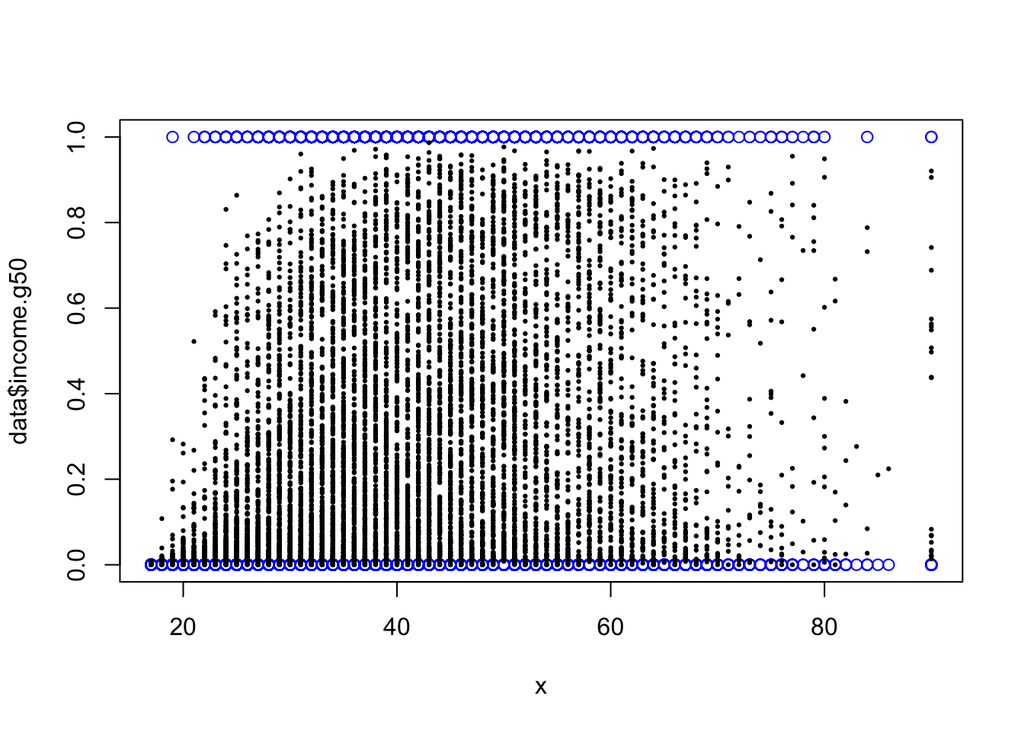

```r
x <- data$age
plot(x, data$income.g50, col="blue")
fits <- fitted(mod)
points(x, fits, pch=19, cex=0.3)
```

No the predicted probabilities do not have the same pattern as the other model as we were not considering the additional variables

```r
tab <- table(data$income.g50, fits>=0.25)
(tab[1,2]+tab[2,1])/sum(tab)
```

```
## [1] 0.2071
```

```r
tab
```

```
##
##     FALSE TRUE
##   0  5853 1690
##   1   381 2076
```

```r
tab <- table(data$income.g50, fits>=0.5)
(tab[1,2]+tab[2,1])/sum(tab)
```

```
## [1] 0.1659
```

```r
tab <- table(data$income.g50, fits>=0.75)
(tab[1,2]+tab[2,1])/sum(tab)
```

```
## [1] 0.1943
```

The cutoff is 0.5 for lowest percent error. However we can see that for all three cutoffs this model has a lower percent error than the other model

4. Plot the ROC and calculate the AUC. Again, does this model out perform the other model?

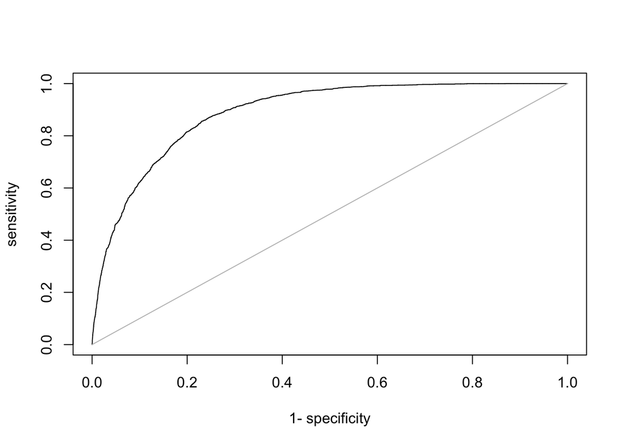

```r
library(AUC)
y <- factor(data$income.g50)
rr <- roc(fits, y)
plot(rr)
```

```r
auc(rr)
```

```
## [1] 0.8893198
```

Extra credit (5 points): Run a k-fold validation on both models and decide which you would prefer to use for predicting high income.

```r
library(caret)
set.seed(10)
mod1 <- createDataPartition(data$income.g50, p =0.6, list = FALSE)
mod1_training <- data[mod1,]
mod1_testing <- data[ -mod1, ]

mod1_fit <- train(income.g50 ~ education + age + sex + race,
data=mod1_training[,!colnames(data)%in%"income"], method="glm", family="binomial")
summary(mod1_fit)
```

```
##
## Call:
## NULL
##
## Deviance Residuals:
##      Min        1Q    Median        3Q       Max
## -2.61190  -0.68465  -0.44399  -0.00176   2.96400
##
## Coefficients:
##                            Estimate Std. Error z value Pr(>|z|)
## (Intercept)                -6.47372    0.58533 -11.060  < 2e-16 ***
## `education 11th`           -0.21579    0.46347  -0.466  0.64151
## `education 12th`            0.84261    0.46310   1.819  0.06884 .
## `education 1st-4th`        -0.35215    0.80611  -0.437  0.66222
## `education 5th-6th`        -1.72357    1.06041  -1.625  0.10408
## `education 7th-8th`         0.08018    0.43543   0.184  0.85391
## `education 9th`            -0.70017    0.55376  -1.264  0.20609
## `education Assoc-acdm`      1.59887    0.35066   4.560 5.13e-06 ***
## `education Assoc-voc`       1.80869    0.33661   5.373 7.73e-08 ***
## `education Bachelors`       2.38522    0.30961   7.704 1.32e-14 ***
## `education Doctorate`       3.23079    0.40351   8.007 1.18e-15 ***
## `education HS-grad`         0.94957    0.30754   3.088  0.00202 **
## `education Masters`         2.88328    0.32342   8.915  < 2e-16 ***
## `education Preschool`     -11.98587  250.09361  -0.048  0.96178
## `education Prof-school`     4.01570    0.39766  10.098  < 2e-16 ***
## `education Some-college`    1.50542    0.30979   4.860 1.18e-06 ***
## age                         0.04388    0.00266  16.498  < 2e-16 ***
## `sex Male`                  1.28178    0.08485  15.106  < 2e-16 ***
## `race Asian-Pac-Islander`   0.68534    0.52321   1.310  0.19024
## `race Black`                0.81425    0.49972   1.629  0.10323
## `race Other`               -0.39980    0.91912  -0.435  0.66358
## `race White`                1.08737    0.48268   2.253  0.02427 *
## ---
## Signif. codes:  0 '***' 0.001 '**' 0.01 '*' 0.05 '.' 0.1 ' ' 1
##
## (Dispersion parameter for binomial family taken to be 1)
##
##     Null deviance: 6726.0  on 5999  degrees of freedom
## Residual deviance: 5334.8  on 5978  degrees of freedom
## AIC: 5378.8
##
## Number of Fisher Scoring iterations: 13
```

```r
set.seed(10)
mod2 <- createDataPartition(data$income.g50, p =0.6, list = FALSE)
mod2_training <- data[mod1,]
mod2_testing <- data[ -mod1, ]

mod2_fit <- train(income.g50~.,
data=data[,!colnames(data)%in%c("income")], method="glm", family="binomial")
summary(mod2_fit)
```

```
##
## Call:
## NULL
##
## Deviance Residuals:
##     Min       1Q   Median       3Q      Max
## -2.6128  -0.5605  -0.2026  -0.0001   3.2983
##
## Coefficients: (2 not defined because of singularities)
##                                               Estimate Std. Error z value
## (Intercept)                                 -9.931e+00  7.766e-01 -12.787
## age                                          2.801e-02  2.783e-03  10.062
## `work.class Federal-gov`                     1.071e+00  2.656e-01   4.032
## `work.class Local-gov`                       1.906e-01  2.418e-01   0.789
## `work.class Never-worked`                   -1.359e+01  9.580e+02  -0.014
## `work.class Private`                         3.800e-01  2.144e-01   1.772
## `work.class Self-emp-inc`                    8.081e-01  2.563e-01   3.153
## `work.class Self-emp-not-inc`                2.786e-01  2.334e-01   1.194
## `work.class State-gov`                       2.782e-01  2.620e-01   1.062
## `work.class Without-pay`                    -1.459e+01  8.999e+02  -0.016
## final.weight                                 1.082e-06  2.937e-07   3.684
## `education 11th`                             5.089e-01  3.490e-01   1.458
## `education 12th`                             6.785e-01  4.153e-01   1.634
## `education 1st-4th`                          2.756e-01  7.168e-01   0.384
## `education 5th-6th`                         -7.479e-01  6.666e-01  -1.122
## `education 7th-8th`                          1.145e-01  3.636e-01   0.315
## `education 9th`                             -2.324e-01  4.387e-01  -0.530
## `education Assoc-acdm`                       1.466e+00  3.018e-01   4.857
## `education Assoc-voc`                        1.473e+00  2.868e-01   5.136
## `education Bachelors`                        2.092e+00  2.668e-01   7.841
## `education Doctorate`                        2.892e+00  3.582e-01   8.075
## `education HS-grad`                          9.690e-01  2.599e-01   3.728
## `education Masters`                          2.429e+00  2.838e-01   8.558
## `education Preschool`                       -1.309e+01  4.975e+02  -0.026
## `education Prof-school`                      3.346e+00  3.489e-01   9.593
## `education Some-college`                     1.412e+00  2.637e-01   5.356
## years.school                                        NA         NA      NA
## `marital.status Married-AF-spouse`           2.779e+00  9.247e-01   3.005
## `marital.status Married-civ-spouse`          2.571e+00  4.121e-01   6.240
## `marital.status Married-spouse-absent`       1.422e-01  3.693e-01   0.385
```

[output cut: 164 more lines]

```
## `native.country Thailand`                   0.983363
## `native.country Trinadad&Tobago`            0.980871
## `native.country United-States`              0.673385
## `native.country Vietnam`                    0.973523
## `native.country Yugoslavia`                 0.426912
## ---
## Signif. codes:  0 '***' 0.001 '**' 0.01 '*' 0.05 '.' 0.1 ' ' 1
##
## (Dispersion parameter for binomial family taken to be 1)
##
##     Null deviance: 11151.2  on 9999  degrees of freedom
## Residual deviance:  6997.9  on 9903  degrees of freedom
## AIC: 7191.9
##
## Number of Fisher Scoring iterations: 15
```

```r
require(glmnet)
ctrl1 <- trainControl(method='cv', number = 10, savePredictions= TRUE)
mod1_fit <- train(income.g50 ~ education + age + sex + race,
data=mod1_training[,!colnames(data)%in%"income"], method="glmnet", family="binomial", trControl = ctrl1, tuneLength = 5)
mod1_fit
```

```
## glmnet
##
## 6000 samples
##    4 predictor
##
## No pre-processing
## Resampling: Cross-Validated (10 fold)
## Summary of sample sizes: 5400, 5400, 5400, 5400, 5400, 5400, ...
## Resampling results across tuning parameters:
##
##   alpha  lambda        RMSE      Rsquared
##   0.100  9.761093e-05  2.112512  0.1987462
##   0.100  4.530698e-04  2.102763  0.1998898
##   0.100  2.102964e-03  2.056956  0.2024680
##   0.100  9.761093e-03  1.948471  0.2048595
##   0.100  4.530698e-02  1.717963  0.2066977
##   0.325  9.761093e-05  2.109674  0.1993630
##   0.325  4.530698e-04  2.095361  0.2008409
##   0.325  2.102964e-03  2.039810  0.2036269
##   0.325  9.761093e-03  1.904109  0.2062397
##   0.325  4.530698e-02  1.637131  0.2009339
##   0.550  9.761093e-05  2.108460  0.1996117
##   0.550  4.530698e-04  2.089179  0.2015054
##   0.550  2.102964e-03  2.025031  0.2044858
##   0.550  9.761093e-03  1.866848  0.2060931
##   0.550  4.530698e-02  1.580146  0.1901418
##   0.775  9.761093e-05  2.107226  0.1998349
##   0.775  4.530698e-04  2.083695  0.2020143
##   0.775  2.102964e-03  2.011499  0.2051879
##   0.775  9.761093e-03  1.835064  0.2047097
##   0.775  4.530698e-02  1.533906  0.1838435
##   1.000  9.761093e-05  2.108575  0.1997058
##   1.000  4.530698e-04  2.078649  0.2024179
##   1.000  2.102964e-03  1.999107  0.2058208
##   1.000  9.761093e-03  1.807436  0.2032376
##   1.000  4.530698e-02  1.494954  0.1734057
##
## RMSE was used to select the optimal model using  the smallest value.
## The final values used for the model were alpha = 1 and lambda = 0.04530698.
```

```r
require(glmnet)

ctrl2 <- trainControl(method='cv', number = 10, savePredictions= TRUE)
mod2_fit <- train(income.g50 ~ .,
data=mod2_training[,!colnames(data)%in%"income"], method="glmnet", family="binomial", trControl = ctrl2, tuneLength = 5)
mod2_fit
```

```
## glmnet
##
## 6000 samples
##   12 predictor
##
## No pre-processing
## Resampling: Cross-Validated (10 fold)
## Summary of sample sizes: 5400, 5400, 5400, 5400, 5400, 5400, ...
## Resampling results across tuning parameters:
##
##   alpha  lambda        RMSE      Rsquared
##   0.100  0.0001873272  3.391498  0.2954836
##   0.100  0.0008694959  3.264319  0.3088248
##   0.100  0.0040358426  3.063534  0.3218671
##   0.100  0.0187327219  2.659499  0.3364397
##   0.100  0.0869495928  2.034587  0.3426070
##   0.325  0.0001873272  3.363995  0.2996995
##   0.325  0.0008694959  3.216310  0.3143754
##   0.325  0.0040358426  2.973859  0.3282963
##   0.325  0.0187327219  2.498792  0.3392534
##   0.325  0.0869495928  1.807363  0.3315967
##   0.550  0.0001873272  3.341562  0.3028005
##   0.550  0.0008694959  3.180946  0.3178404
##   0.550  0.0040358426  2.903717  0.3323559
##   0.550  0.0187327219  2.382864  0.3394693
##   0.550  0.0869495928  1.694973  0.3216225
##   0.775  0.0001873272  3.324093  0.3051489
##   0.775  0.0008694959  3.152301  0.3203844
##   0.775  0.0040358426  2.845905  0.3352556
##   0.775  0.0187327219  2.305106  0.3371358
##   0.775  0.0869495928  1.629935  0.3014992
##   1.000  0.0001873272  3.309471  0.3070197
##   1.000  0.0008694959  3.127255  0.3224416
##   1.000  0.0040358426  2.795900  0.3374457
##   1.000  0.0187327219  2.254632  0.3346807
##   1.000  0.0869495928  1.585519  0.2946330
##
## RMSE was used to select the optimal model using  the smallest value.
## The final values used for the model were alpha = 1 and lambda = 0.08694959.
```

Thus we can see that after performing k cross validation the second model has a better R-squared on most predictors than the first model